# Performance of Chocolate Bar

#### *August 17, 2019*

# Introduction

#### Why Chocolate Bar?

North Americans prefer chocolates on multiple occasions such as festivals and good luck wishes, etc. Nutella is one of the prominent brands for chocolate. It produces chocolate using rich cocoa and hazelnut. Due to immense sell and preference, a cocoa export company has gathered the data and looking to start manufacturing chocolate. But before taking any step, it is important to understand the changing preference of chocolate containing cocoa level respect to time and cocoa bean location.

#### Why it is important for a Cocoa export company to perform analysis on the data?

The organization wants to target North America. So, it is important to understand the choice of North Americans. Over time the trend has changed from sugary chocolate to low-calorie dark chocolate. To build the operation appropriately, the organization has hired a management consulting firm to perform data analysis.

#### Project Goal and Dataset description

Exploratory analysis is a statistical analysis which provides insights, hidden patterns, and the relationship between multiple attributes of the data set. After satisfactory analysis, a statistical predictive model will be built for future reference.

The data set contains more than 1700 observations and 9 attributes. The attributes of the data set are a company, bar/bean origin, recent or old review, review year, cocoa percentage, manufacturer location, rating of the bar, bean type, broad bean origin.

Rating System:

- 5 = Elite
- 4 = Premium
- 3 = Satisfactory
- 2 = Disapponting
- 1 = Unpleasant

From the above ratings, it can be said that review less than 3 means it is **not good** and for rest, it is **good**.

##### Target Variable:

Based on the predictors/independent variables, the model will help to predict the rating of that chocolate product. Predicting the ratings of chocolate would be Target Variable.

##### Exploratory/Predictor Variables:

- **Name of the Company manufacturing the bar**: A categorical variable represents the name of the manufacturer
- **Review Date**: A numerical discrete variable presents in which year the reviews were taken
- **Cocoa Percent**: A continous numerical variable describes the percentage level of cocoa in a bar/chocolate
- **Company Location**: A categorical variable provides information of main campus of manufacturer
- **Rating**: A continuous numerical variable provides ratings of chocolate/bar

```r
#loadint the required library to perform the operation.
library(tidyverse)
```

```r
library(ggplot2)
library(gridExtra)
#Loading the Data set and assigning column name for better understanding.
dataSet <- read.csv("/Users/mihirthakkar/Downloads/flavors_of_cacao.csv",header = TRUE)
colnames(dataSet) <- c("Company","Bean_Origin","REF","Review_Date","Cocoa_Percent","Company_Location","Rating","Bean_Type","Broad_Bean_Orign")
```

# Feature Engineering

```r
#It is important to understand how data looks like. Head will return few first rows and all the columns value
dataSet %>% head()
```

```
##    Company Bean_Origin  REF Review_Date Cocoa_Percent Company_Location
## 1 A. Morin Agua Grande 1876        2016           63%           France
## 2 A. Morin       Kpime 1676        2015           70%           France
## 3 A. Morin      Atsane 1676        2015           70%           France
## 4 A. Morin       Akata 1680        2015           70%           France
## 5 A. Morin      Quilla 1704        2015           70%           France
## 6 A. Morin    Carenero 1315        2014           70%           France
##   Rating Bean_Type Broad_Bean_Orign
## 1   3.75                   Sao Tome
## 2   2.75                       Togo
## 3   3.00                       Togo
## 4   3.50                       Togo
## 5   3.50                       Peru
## 6   2.75   Criollo        Venezuela
```

```r
#calculate missing values in each column
dataSet %>% is.na() %>% colSums()
```

```
##          Company      Bean_Origin              REF      Review_Date
##                0                0                0                0
##    Cocoa_Percent Company_Location           Rating        Bean_Type
##                0                0                0                0
## Broad_Bean_Orign
##                0
```

```r
#calculate numerical summary of data that provides mean, median, 1st and 3rd Qu., and Range
dataSet %>% summary()
```

```
##      Company                 Bean_Origin        REF        Review_Date
##  Soma    :  47   Madagascar        :  57   Min.   :   5   Min.   :2006
##  Bonnat  :  27   Peru              :  45   1st Qu.: 576   1st Qu.:2010
##  Fresco  :  26   Ecuador           :  42   Median :1069   Median :2013
##  Pralus  :  25   Dominican Republic:  37   Mean   :1036   Mean   :2012
##  A. Morin:  23   Venezuela         :  21   3rd Qu.:1502   3rd Qu.:2015
##  Arete   :  22   Chuao             :  19   Max.   :1952   Max.   :2017
##  (Other) :1625   (Other)           :1574
##  Cocoa_Percent Company_Location     Rating                     Bean_Type
##  70%    :672   U.S.A. :764      Min.   :1.000                       :887
##  75%    :222   France :156      1st Qu.:2.875   Trinitario          :419
##  72%    :189   Canada :125      Median :3.250   Criollo             :153
##  65%    : 78   U.K.   : 96      Mean   :3.186   Forastero           : 87
##  80%    : 72   Italy  : 63      3rd Qu.:3.500   Forastero (Nacional): 52
##  74%    : 50   Ecuador: 54      Max.   :5.000   Blend               : 41
##  (Other):512   (Other):537                      (Other)             :156
##            Broad_Bean_Orign
##  Venezuela         :214
##  Ecuador           :193
##  Peru              :165
##  Madagascar        :145
##  Dominican Republic:141
##                    : 73
##  (Other)           :864
```

Calculate categorical variables, including `NA` as a category

```r
nrow(is.na(dataSet$Company_Location))
```

[output not shown]

```r
#Cocoa percent contain percentage so it is difficult to perform operation. Convert into character and split the numeric and percentage sign.
# Converting Cocoa_Percent to Character to make it proper numeric entity
dataSet$Cocoa_Percent <- as.character(dataSet$Cocoa_Percent)
dataSet$Cocoa_Percent <- strsplit(dataSet$Cocoa_Percent,split = "%")
dataSet$Cocoa_Percent <- as.numeric(dataSet$Cocoa_Percent)

#For future operation, Converted Company location to Character. As we will need to split the data as per continent.
dataSet$Company_Location  <- as.character(dataSet$Company_Location)
```

##### Exploratory Analysis of Data Set:

##### Company Location:

```r
#Finding unique categorical values
dataSet$Company_Location %>% unique()
```

```
##  [1] "France"            "U.S.A."            "Fiji"
##  [4] "Ecuador"           "Mexico"            "Switzerland"
##  [7] "Netherlands"       "Spain"             "Peru"
## [10] "Canada"            "Italy"             "Brazil"
## [13] "U.K."              "Australia"         "Wales"
## [16] "Belgium"           "Germany"           "Russia"
## [19] "Puerto Rico"       "Venezuela"         "Colombia"
## [22] "Japan"             "New Zealand"       "Costa Rica"
## [25] "South Korea"       "Amsterdam"         "Scotland"
## [28] "Martinique"        "Sao Tome"          "Argentina"
## [31] "Guatemala"         "South Africa"      "Bolivia"
## [34] "St. Lucia"         "Portugal"          "Singapore"
## [37] "Denmark"           "Vietnam"           "Grenada"
## [40] "Israel"            "India"             "Czech Republic"
## [43] "Domincan Republic" "Finland"           "Madagascar"
## [46] "Philippines"       "Sweden"            "Poland"
## [49] "Austria"           "Honduras"          "Nicaragua"
## [52] "Lithuania"         "Niacragua"         "Chile"
## [55] "Ghana"             "Iceland"           "Eucador"
## [58] "Hungary"           "Suriname"          "Ireland"
```

Company Location has more than 50 entities as unique and if we consider it in the logistic regression then we might not get the proper prediction of rating.

# Single and Multiple Variable Visualization:

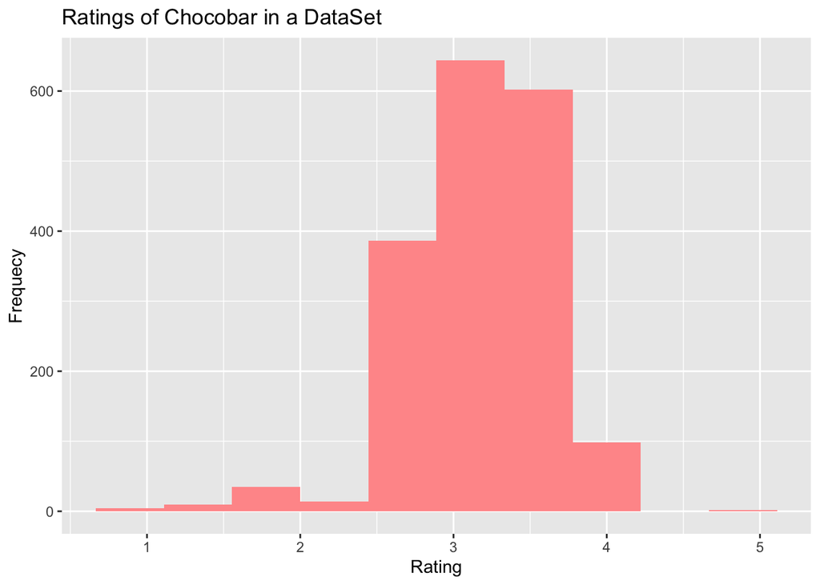

```r
#Dispersion of Rating in the Data Set
dataSet %>% ggplot(aes(x = Rating)) + geom_histogram(fill = '#FF9999',bins =10) + xlab("Rating") + ylab("Frequecy") +  ggtitle("Ratings of Chocobar in a DataSet")
```

The histogram represents that most of the ratings of the chocolate bar lie between 2.5 to 4.3 value. These values are approximate based on the visualization.

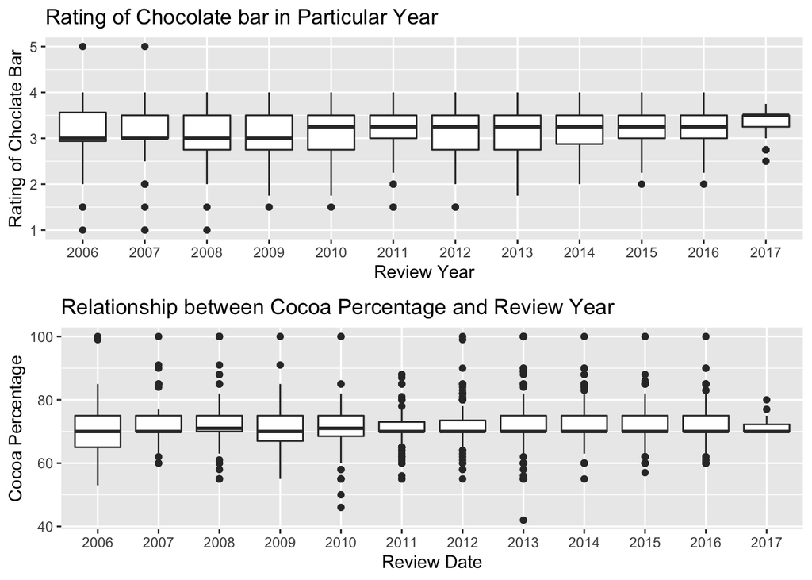

```r
#Relation of Rating with other years
g2 <- dataSet %>% ggplot(aes(x = as.factor(Review_Date), y = Rating)) + geom_boxplot() +
  xlab("Review Year") + ylab("Rating of Choclate Bar") + ggtitle("Rating of Chocolate bar in Particular Year")

#Identifying relationship between cocoa percentage and review year
g3 <- dataSet %>% ggplot(aes(x = as.factor(Review_Date), y = Cocoa_Percent)) + geom_boxplot() +
  xlab("Review Date") + ylab("Cocoa Percentage") + ggtitle("Relationship between Cocoa Percentage and Review Year")

#Making a single graph to compare how rating and cocoa percentage changing over the time
grid.arrange(g2,g3)
```

The reason behind less entity creates questions such as:

- Whether people have reduced consuming chocolate?
- Are not any new chocolates available to taste?

One thing can be inferred from the view that data is skewed for most of the years.

Most of the ratings have a cocoa percentage between 60-80 and that means that people do prefer cocoa percentage more in the chocolate bar. Also,Data is dispersed and the most important question comes that data does not have equivalent values for a couple of years and what is the reason behind this?

##### Review of Chocolate Bar change:

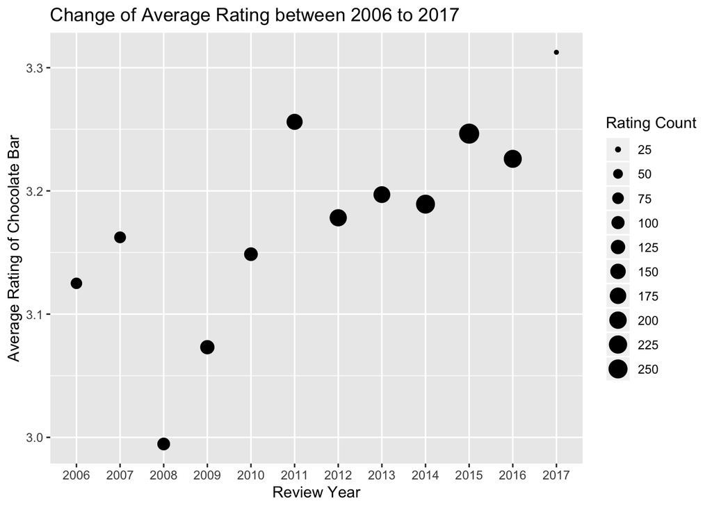

```r
#Aggregate Data and make data as per review date
reviewDateGroup <- dataSet %>%
  group_by(Review_Date) %>%
  summarise(Count = n(), AvgRat= mean(Rating))

#Check average change of rate thgouhout the years of data
reviewDateGroup %>% ggplot(aes(factor(Review_Date),AvgRat)) +
                    geom_point(aes(size = Count)) +
                    xlab("Review Year") + ylab("Average Rating of Chocolate Bar") +
                    ggtitle("Change of Average Rating between 2006 to 2017")+
                    scale_size(breaks = seq(0,250,25),name = "Rating Count")
```

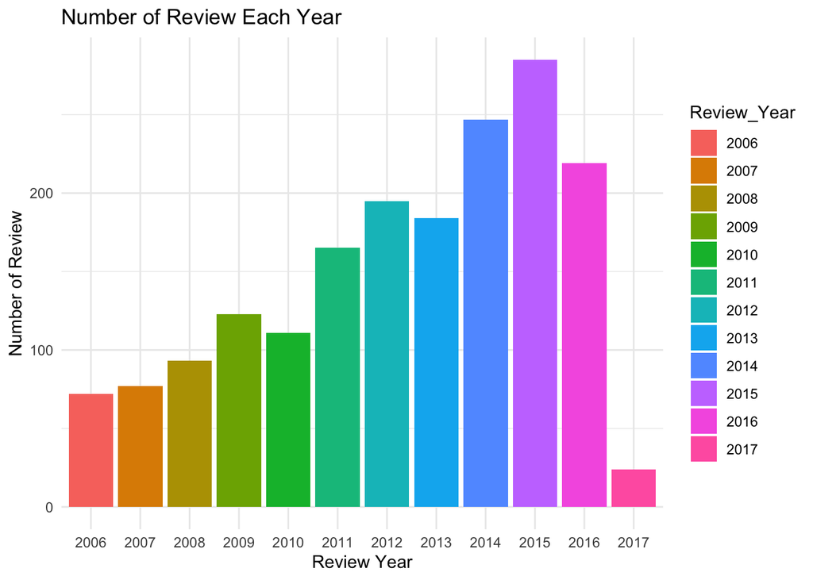

```r
Review_Year <- as.factor(reviewDateGroup$Review_Date)
reviewDateGroup %>% ggplot(aes(x = factor(Review_Date),y= Count, fill =Review_Year)) + geom_bar(stat = 'identity') +
                    theme_minimal() +
                    xlab("Review Year") + ylab("Number of Review") +
                    ggtitle("Number of Review Each Year")
```

The bar graph showcases that the amount of observations from each year is not the same so concluding with these varying data is not an appropriate solution. The result might not be good but if we combine all the data value then average rating with cocoa percentage remains equivalent for almost years and observations.

```r
#It is important to identify the correlation between variables before making model
library(corrplot)
m <- subset.data.frame(dataSet,select = c('Review_Date','Rating','Cocoa_Percent'))
m$Review_Date <- as.integer(m$Review_Date)
m$Rating <- as.numeric(m$Rating)
m$Cocoa_Percent <- as.numeric(m$Cocoa_Percent)
corVal <- cor(m)
print(cor(m))
```

```
##               Review_Date     Rating Cocoa_Percent
## Review_Date     1.0000000  0.0998465     0.0381769
## Rating          0.0998465  1.0000000    -0.1648202
## Cocoa_Percent   0.0381769 -0.1648202     1.0000000
```

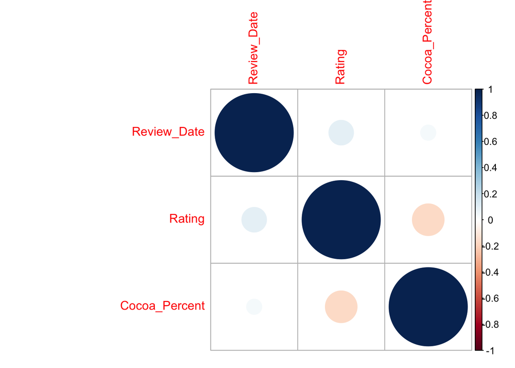

```r
corrplot(corVal)
```

##### A subset of dataset containing information about Company location = USA or Canada

```r
#Aggregate and Fiter Data to create Subset data
beanData <- dataSet %>%
  filter(Company_Location == "U.S.A." | Company_Location == "Canada") %>%
  group_by(Review_Date,Company_Location,Rating, Cocoa_Percent) %>%
  summarise()

#Convert the charcter value to factor
beanData$Company_Location <- as.factor(beanData$Company_Location)

beanData %>% summary()
```

```
##   Review_Date   Company_Location     Rating      Cocoa_Percent
##  Min.   :2006   Canada: 85       Min.   :1.500   Min.   : 55.00
##  1st Qu.:2011   U.S.A.:384       1st Qu.:2.750   1st Qu.: 70.00
##  Median :2013                    Median :3.250   Median : 72.00
##  Mean   :2013                    Mean   :3.145   Mean   : 72.09
##  3rd Qu.:2015                    3rd Qu.:3.500   3rd Qu.: 75.00
##  Max.   :2017                    Max.   :4.000   Max.   :100.00
```

##### Relationship Between Cocoa Percentage in Chocolate with Rating and it will be identified for every review date.

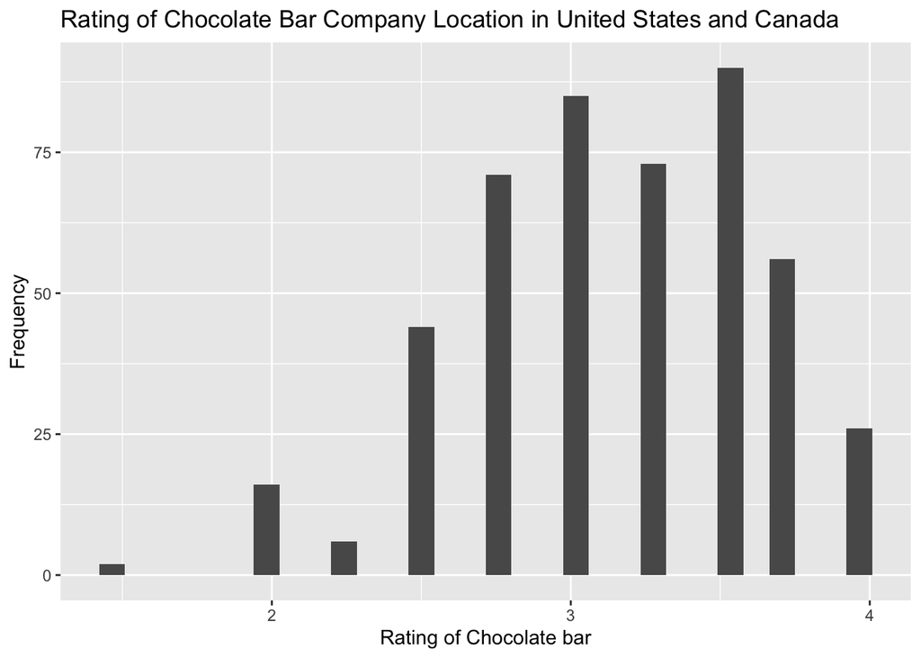

```r
beanData %>% ggplot(aes(Rating)) + geom_histogram() +
              xlab("Rating of Chocolate bar") + ylab("Frequency") +
              ggtitle("Rating of Chocolate Bar Company Location in United States and Canada")
```

It seems that visualization follows a similar pattern found in the original data set. For the subset of data set two of the algorithm should be followed.

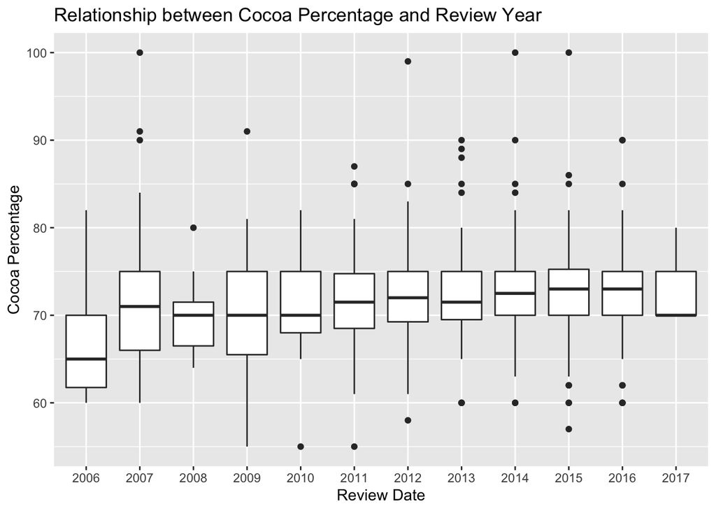

```r
beanData %>% ggplot(aes(x = as.factor(Review_Date), y = Cocoa_Percent)) + geom_boxplot() +
  xlab("Review Date") + ylab("Cocoa Percentage") + ggtitle("Relationship between Cocoa Percentage and Review Year")
```

The data is dispersed and do not have the same amount of attributes in every year. Also, Cocoa percentage is skewed in the data.

Over the time study has proven that dark chocolate is good for health as well as good to keep blood pressure in a proper range.

Before couple of years preference of american was milk chocolate over dark chocolate till 2010. (Statista, 2012), [Milk and dark chocolate consumption in the United States in 2010 by age group](https://www.statista.com/statistics/238730/milk-and-dark-chocolate-consumption-in-the-us-by-age-group/)

Over the years preference has been changed, Americans prefer chocolates with less sugar, less fat, and calorie, as well as more dark due to the health benefit of dark cocoa. The market for dark chocolate is expected to expand about approx. 7%. (Grand View Research, Jan 2018), [North America Chocolate Market Size Worth $42.16 Billion by 2025](https://www.grandviewresearch.com/press-release/north-america-chocolate-market-analysis)

#### **Note**

Since our target is North America, it is not important to visualize the other continent. With the visualization, it can be inferred that the data seems not suitable for prediction.

# Model Building and Performance:

```r
#Converting Rating to Good or Not good.
#Converting Rating <3 to 0 which means Not Good else it is 1 means Good
beanData$Rating <- if_else(beanData$Rating <3, "Not Good","Good")

#To use feature in mdoel, it is important to convert it to factor so model will not consider it as numeric value and assign degree order.
beanData$Rating <- as.factor(beanData$Rating)
```

**1. Introduction to the Model:** Our approach is to identify Good and Not Good Chocolate bar. So we decided to move forward with logistic classification. The model will produce output in a probability manner. That probability will define the classifier in output.

**The model formula will be:** Rating ~ Review_Date + Company_Location + Cocoa_Percent.

**2. Fit the Model:** We will use 70:30 split ratio and we will divide the data set using splitting ration: train and test data set.

```r
#Spliting Data in to Train and Test data set to train and test the model.
set.seed(123)
train_index <- sample(1:nrow(beanData),0.7*nrow(beanData))
test_index <- setdiff(1:nrow(beanData),train_index)

trainD <- beanData[train_index,]
testD <- beanData[-train_index,]
```

**Building a logistic model**

```r
model <- glm(Rating ~ Review_Date + Cocoa_Percent + Company_Location,data = trainD, family = binomial)
summary(model)
```

```
##
## Call:
## glm(formula = Rating ~ Review_Date + Cocoa_Percent + Company_Location,
##     family = binomial, data = trainD)
##
## Deviance Residuals:
##     Min       1Q   Median       3Q      Max
## -1.0264  -0.8714  -0.8241   1.4550   1.9254
##
## Coefficients:
##                        Estimate Std. Error z value Pr(>|z|)
## (Intercept)            63.47701   90.76555   0.699    0.484
## Review_Date            -0.03284    0.04511  -0.728    0.467
## Cocoa_Percent           0.01509    0.01739   0.868    0.386
## Company_LocationU.S.A.  0.73856    0.37838   1.952    0.051 .
## ---
## Signif. codes:  0 '***' 0.001 '**' 0.01 '*' 0.05 '.' 0.1 ' ' 1
##
## (Dispersion parameter for binomial family taken to be 1)
##
##     Null deviance: 394.80  on 327  degrees of freedom
## Residual deviance: 388.86  on 324  degrees of freedom
## AIC: 396.86
##
## Number of Fisher Scoring iterations: 4
```

**3. Model Regression Coefficients Interpretation:**

- Intercept has a positive value.
- If we check p-value for particular data set then the p-value is so high that it is not significant to rely on this model.

**4. Model Regression Coefficients Interpretation:** It is always important to test the built model. To verify the accuracy of the test model, We will use the test data set and predict the outcome of the variable.

```r
#Model Predicted and stored in a variable for future reference
y_pred = predict(object = model,newdata = testD)
```

```r
#Converting Probability value in to Factor for better understanding
y_pred <- if_else(y_pred >0.5, "Good","Not Good")
y_pred <- as.factor(y_pred)
```

To identify how the model performs. We have simply calculated unique values in both the test data set and predicted data set.

```r
#creating matrix for perfoamnce
#Let us calculate Not good values in the model.
a1 <- testD$Rating %>% summary()
a1
```

```
##     Good Not Good
##       97       44
```

```r
a2 <- y_pred %>% summary()
a2
```

```
## Not Good
##      141
```

# Conclusions:

- As per the model calculation, there are no **Good** Values and all we got is **Not good** values. We got 141 **Not Good** values. A model is having 100% one value seems weird. The model is not good to rely on.
- Since the model output is not good so I would not prefer to look at the precision and recall. If a model has some relevant information and valid answer then it makes sense to go with the precision or recall. But it seems that the model is 30% accurate to predict the value.

We mentioned in the note that we might not get good model although we have correlation but predictive model seems not good. As per expectation the model is not good.

**Note to Organization:** * As a data analyst, I would suggest not to use a model and change the data set. Also, for successful operation, an analyst of the organization must look for recent changes and trends. It is more important to know the current competition and preferences then relying on the predictive model only.